# act_report

## Report: act_report

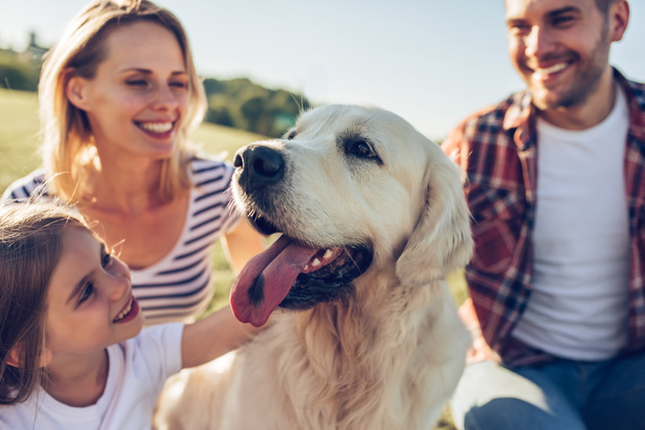

source: Purely pets

They say dog is a mans best friend, a very good companion. Do you like dogs, you have one or would like to have one? Stay with me, as i show how i analzed tweets gathered from the WeRateDogs page (@dog_rates), where cute pics of dogs are rated, retweeted and favourited. One of the interesting thing about the rating of dogs is that dogs can be rated above the denominator figure which is 10, a dog can be 13/10, 50/10, or 1000/10.

[figure not shown]

The WeRateDogs is one of the most popular dog rate page with over 9 million followers and 5000+ tweets, which is why I decided to explore it.

Analyzing the dataset did not come before wrangling of the data which consists of gathering the data from different sources, assess the data to check for quality and tidiness issues, which then was cleaned.

**Analyzing the data**

One of the uniqueness of the WeRateDogs is there rating system, which can be above 10 but for the purpose of this analysis I would be limiting the numerator to a maximum of 15.

I start by analyzing the correlation between the pair of favourite counts, retweet count and ratings.